# Rapport

Juliette SIEBERING, Adeline VERCOUTRE

P26

```r
library(ggplot2)
library(dplyr)
library(stringr)
library(viridis)
library(tidyverse)
library(ggrepel)
```

# Introduction

Notre jeu de données regroupe tous les jeux publiés sur Steam jusque mars 2025, avec de nombreuses informations comme le prix, le système d’exploitation, la date de publication, etc… (voir tableau ci-dessous).

| Catégorie - sous-groupe | Variable | Format | Type |
| --- | --- | --- | --- |
|  | appid | int | discrète |
|  | name | chr | nominale |
|  | release_date | chr | date |
|  | required_age | int | discrète |
|  | price | num | continue |
|  | dlc_count | int | discrète |
|  | detailed_description | chr | nominale |
|  | about_the_game | chr | nominale |
|  | short_description | chr | nominale |
|  | reviews | chr | nominale |
|  | header_image | chr | nominale |
|  | website | chr | nominale |
|  | support_url | chr | nominale |
|  | support_email | chr | nominale |
| Système d’exploitation | windows | chr | discrète |
| Système d’exploitation | mac | chr | discrète |
| Système d’exploitation | linux | chr | discrète |
|  | metacritic_score | int | discrète |
|  | metacritic_url | chr | nominale |
|  | achievements | int | discrète |
|  | recommendations | int | discrète |
|  | notes | chr | nominale |
|  | supported_languages | chr | nominale |
|  | full_audio_languages | chr | nominale |
|  | packages | chr | nominale |
|  | developers | chr | nominale |
|  | publishers | chr | nominale |
|  | categories | chr | nominale |
|  | genres | chr | nominale |
|  | screenshots | chr | nominale |
|  | movies | chr | nominale |
|  | user_score | int | discrète |
|  | score_rank | int | discrète |
| Nombre de reviews | positive | int | discrète |
| Nombre de reviews | negative | int | discrète |
|  | estimated_owners | chr | nominale |
| Moyenne temps de jeu | average_playtime_forever | int | discrète |
| Moyenne temps de jeu | average_playtime_2weeks | int | discrète |
| Médiane temps de jeu | median_playtime_forever | int | discrète |
| Médiane temps de jeu | median_playtime_2weeks | int | discrète |
|  | discount | int | discrète |
|  | peak_ccu | int | discrète |
|  | tags | chr | nominale |
| Pourcentage de reviews positives | pct_pos_total | int | discrète |
| Nombre de reviews | num_reviews_total | int | discrète |
| Pourcentage de reviews positives | pct_pos_recent | int | discrète |
| Nombre de reviews | num_reviews_recent | int | discrète |

Les données proviennentt du site Kaggle. Nous avons choisi ce jeu en particulier pour sa richesse (89618 observations et 47 variables) et pour sa récence (les données datent de mars 2025). Étant tous des joueurs dans le groupe, cela nous paraît intéressant de voir les données concernant nos jeux préférés.

Pour avoir une cohérence dans notre exploration, nous avons décidé de la diviser en deux sections : les potentiels facteurs impactant les ventes d’un jeu et la qualité d’un jeu selon différentes variables.

Le dataset contient de nombreuses variables que nous n’allons pas utiliser, telles que les descriptions, les liens vers le support du jeu ou des vidéos prises en jouant. Pour la rapidité de calcul et la légèreté du fichier, nous allons les supprimer de notre jeu de données. La sélection a été faite après avoir réalisé la plupart de nos visualisations, pour nous assurer de garder les variables nécessaires à notre rapport.

```r
# Ce qui se trouve dans ce chunk a déjà été réalisé au préalable, mais nous tenions à l'inclure das le rapport pour expliciter notre démarche

# Le fichier originel étant trop lourd pour GitHub, il n'est pas dans le dossier partagé, mais sur nos ordinateurs, d'où le '../..' au lieu de '../data'
# jeux <- read.csv('../../games_march2025_cleaned.csv')

# On retire les variables non  pertinentes
# jeu_allege <- jeux %>% select(-c(dlc_count, detailed_description, about_the_game, short_description, reviews, header_image, website, support_url, support_email, metacritic_url, achievements, notes, packages, screenshots, movies, peak_ccu, tags))

# Ce jeu allégé peut être déposé sur GitHub, puisqu'il fait moins de 100Mo.
# write.csv(jeu_allege, "../data/jeux_alleges.csv", row.names = FALSE)
```

Comme nous l’avons vu dans le tableau décrivant chaque donée, certaines d’entre elles ne sont pas du bon format d’après RStudio, comme *release_date* et les différents systèmes d’exploitaion, qui sont tous des chaînes de caractère alors qu’ils devraient être respectivement des dates et des booléens. De plus, les genres, les studios de développement et les langues supportées, que nous allons utiliser par la suite, sont également considérés comme des chaînes de caractère, alors que ce sont des listes. Il faut donc corriger cela.

```r
# On récupère les données de notre jeu allégé
jeu_allege <- read.csv("C:/Users/adeli/Downloads/jeux_alleges.csv")

# On transforme les fausses listes en véritables listes (genres, studio de développement, langues supportées)
jeu_allege <- jeu_allege %>% mutate(
  genres = str_remove_all(genres, "\\[|\\]|'"),
  genres = str_split(genres, ",\\s*"),

  categories = str_remove_all(categories, "\\[|\\]|'"),
  categories = str_split(categories, ",\\s*"),

  developers = str_remove_all(developers, "\\[|\\]|'"),
  developers = str_split(developers, ",\\s*"),

  supported_languages = str_remove_all(supported_languages, "\\[|\\]|'"),
  supported_languages = str_split(supported_languages, ",\\s*")
  )

# On transforme les chaînes de caractère "TRUE" et "FALSE" en booléens
jeu_allege <- jeu_allege %>%
  mutate(
    windows = as.logical(windows),
    mac     = as.logical(mac),
    linux   = as.logical(linux)
  )

# On met les dates au bon format
jeu_allege$release_date <- as.Date(jeu_allege$release_date)
```

Maintenant que notre jeu de données est pleinement exploitable, il est temps de l’explorer.

# Y a-t-il des facteurs qui impactent les ventes d’un jeu ?

Pour répondre à notre problématique principale, nous allons utiliser la variable *estimated_owners*. Cette variable est une chaîne de caractère représentant une fourchette d’entiers. Actuellement, on peut y voir “100000 - 200000” ou “200000000 - 500000000”, ce qui n’est pas très lisible sur une visualisation. Il faut donc formater ces chaînes de caractère, et les mettre dans le bon ordre, pour avoir sur nos graphiques les fourchettes de la plus petite à la plus grande.

```r
# On formate les nombres pour passer de "10000000" à "10M"
format_number <- function(n) {
  if (n >= 1e6) {
    paste0(round(n / 1e6, 1), "M") # Si le nombre est au moins 1 million, on le remplace par "...M"

  } else if (n >= 1e3) {
    paste0(round(n / 1e3, 1), "K") # Si le nombre est au moins 1 millier, on le remplace par "...K"

  } else {
    as.character(n)
  }
}

# On formate les intervalles d'acheteurs pour passer de "10000000 - 20000000" à "10M - 20M"
format_range <- function(x) {

  sapply(strsplit(x, " - "), function(parts) { # Pour chaque intervalle, on divise la chaîne de caractère en 2 parties

    parts <- as.numeric(parts) # On convertit ces 2 parties en nombre

    paste0( # On crée une nouvelle chaîne contenant :
      format_number(parts[1]), # Le nombre bas de la fourchette formaté avec la fonction "format_number",
      " - ", # La chaîne de caractère permettant de séparer les deux extrémités de la fourchette
      format_number(parts[2]) # Et le nombre haut de la fourchette formaté avec la fonction "format_number"
    )
  })
}

# On récupère toutes les fourchettes distinctes d'acheteurs
fourchettes_owners <- unique(jeu_allege$estimated_owners)

# On classe ces fourchettes de la plus basse à la plus haute grâce à leurs parties numériques
ordre_fourchettes <- fourchettes_owners[order(sapply(strsplit(fourchettes_owners, " - "), function(x) as.numeric(x[1])))]

# On formate nos fourchettes dans une nouvelle variable, et on leur applique l'ordre décrit précédemment grâce à la fonction factor
jeu_allege$fourchettes_affichage <- factor(format_range(jeu_allege$estimated_owners),levels = format_range(ordre_fourchettes))
```

Maitenant que nos fourchettes sont dans un format lisible, commençons par regarder combien de jeux sont dans chaque fourchette. Cela nous permettra de mieux interpréter les informations de nos différentes visualisations.

```r
# On crée un tableau permettant de voir combien de jeux sont associés à chaque fourchette
nb_jeux_owners <- jeu_allege %>% count(fourchettes_affichage) %>% select(fourchettes_affichage, `Nombre de jeux` = n)

# On affiche ce tableau
nb_jeux_owners
```

```
##    fourchettes_affichage Nombre de jeux
## 1                  0 - 0           8418
## 2                0 - 20K          59320
## 3              20K - 50K           9683
## 4             50K - 100K           4552
## 5            100K - 200K           3005
## 6            200K - 500K           2469
## 7              500K - 1M           1038
## 8                1M - 2M            574
## 9                2M - 5M            373
## 10              5M - 10M            108
## 11             10M - 20M             42
## 12             20M - 50M             24
## 13            50M - 100M             10
## 14           100M - 200M              1
## 15           200M - 500M              1
```

On voit ici qu’il n’y a que 2 jeux qui ont plus de 100 millions d’acheteurs, ce qui signifie que les 2 dernières fourchettes ne sont pas comparables aux autres. La fourchette suivante ne contient que 10 jeux, ce qui est également très peu. Regardons quels sont ces 12 jeux.

```r
# On filtre les jeux pour n'avoir que ceux qui appartiennent aux 3 dernière fourchettes
top_12_jeux <- jeu_allege %>%
  filter(fourchettes_affichage == "200M - 500M" |
         fourchettes_affichage == "100M - 200M" |
        fourchettes_affichage == "50M - 100M") %>%
  select(name, fourchettes_affichage)

# On affiche ces jeux
top_12_jeux
```

```
##                         name fourchettes_affichage
## 1           Counter-Strike 2           100M - 200M
## 2        PUBG: BATTLEGROUNDS            50M - 100M
## 3                     Dota 2           200M - 500M
## 4  Grand Theft Auto V Legacy            50M - 100M
## 5              Apex Legends™            50M - 100M
## 6         Black Myth: Wukong            50M - 100M
## 7              HELLDIVERS™ 2            50M - 100M
## 8                   Unturned            50M - 100M
## 9              Call of Duty®            50M - 100M
## 10                  Palworld            50M - 100M
## 11       New World: Aeternum            50M - 100M
## 12                  Lost Ark            50M - 100M
```

On peux voir que *Dota 2* est le jeu le plus vendu de Steam, suivi de *Counter Strike 2*.

Maintenant que nous avons ces informations, nous pouvons voir le premier facteur.

## 1er facteur : le prix

L’un des premiers facteurs qui nous vient à l’esprit est le prix, nous allons donc observer les variables *price* et *estimated_owners* pour répondre à la question suivante :

#### Y a-t-il une corrélation entre le prix d’un jeu et ses ventes ?

Etant donné que nous cherchons à montrer une évolution de la proportion du prix en fonction du nombre d’acheteurs, un line chart est une visualisation adaptée.

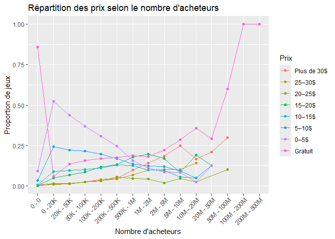

```r
# On copie notre jeu pour ne pas l'altérer
data_date <- jeu_allege

# On ajoute une variable à data, contenant les fourchettes associées au prix de chaque jeu
data_date$prix_cat <- cut(data_date$price, # On découpe les prix en intervalles
  breaks = c(-0.01, seq(0, 30, 5), Inf), # Ces intervalles vont de -0.01 à Inf, de 5 en 5 en s'arrêtant à 30, pour avoir les jeux gratuits : ]-0.01-0] et payants : ]0-5] etc... jusque ]30-Inf[
  labels = c("Gratuit", paste0(seq(0, 25, 5), "–", seq(5, 30, 5), "$"), "Plus de 30$"), # On donne un nom à chaque intervalle
)

# On crée l'ordre croissant des fourchettes de prix pour avoir un graphique lisible
ordre_prix <- c("Gratuit", paste0(seq(0, 25, 5), "–", seq(5, 30, 5), "$"), "Plus de 30$")

# On applique cet ordre à notre jeu
data_date$prix_cat <- factor(data_date$prix_cat, levels = rev(ordre_prix))

# On calcule la répartition des jeux selon leur catégorie de prix et leur nombre d'acheteurs
repartition_prix <- data_date %>%
  count(fourchettes_affichage, prix_cat) %>% # On compte le nombre de jeux pour chaque combinaison fourchette d’acheteurs - catégorie de prix
  group_by(fourchettes_affichage) %>% # On regroupe ce décompte par fourchette pour calculer les proportions
  mutate(prop = n / sum(n)) %>% # On ajoute la variable prop, dans laquelle on stocke la proportion de chaque catégorie de prix par fourchette
  ungroup() # On retire la structure groupée

# On crée notre visualisation
ggplot(repartition_prix, aes(x = fourchettes_affichage, y = prop, group = prix_cat, color = prix_cat)) +

  geom_line() + # On fait un line chart pour montrer l'évolution de la proportion
  geom_point()  + # On met les points pour mieux voir où s'arrête l'évolution

  labs(
    title = "Répartition des prix selon le nombre d'acheteurs",
    x = "Nombre d'acheteurs",
    y = "Proportion de jeux",
    color = "Prix"
  ) + # On ajoute titre, nom des axes et légende

  theme(axis.text.x = element_text(angle = 45, hjust = 1)) # On incline l'axe des x pour pouvoir lire les fourchettes
```

Grâce à cette visualisation, nous pouvons observer plusieurs choses, notamment que la proportion de jeux gratuits augmentent avec les nombre d’acheteurs, même en oubliant les 2 dernières fourchettes, qui ne contiennent qu’un jeu chacune. Cela paraît logique puisque les jeux gratuits sont les plus accessibles.

Fait plus étonnant, le nombre de jeux de plus de 30$ augmente également avec le nombre d’acheteurs. Cela semble contre-intuitif, mais une très bonne réputation, une boîte de production célèbre ou des critiques très positives sur le graphisme, le gameplay ou les personages peuvent justifer et faire oublier le prix “élevé” d’un jeu.

Nous pouvons également constater que la gratuité ne fait pas la vente, puisque plus de près de 87% des jeux invendus sont gratuits. Cela peut être dû à une mauvais réputation, un manque de publicité ou des images peu attrayantes.

Nous pouvons également voir que la variété des prix diminue avec le nombre d’acheteurs. Plus les tranches sont élevées, moins il y a de fourchettes de prix différentes. Nous ne voyons pas d’explication à ce phénomène.

Toutes ces observatios nous permette de supposer que le prix a certes un impact sur les ventes, mais d’autres facteurs entrent sûrement en jeu lors de l’achat d’un jeu vidéo.

## 2ème facteur : la limite d’âge

Lorsque l’on achète un jeu, il n’est pas rare qu’une limite d’âge soit affichée, que ce soit pour prévenir de la vulgarité, de la violence ou de la peur que peut provoquer un jeu, le fameux PEGI. Cette limite d’âge peut représenter un frein lors de l’achat d’un jeu, du moins c’est ce que nous aimerions savoir, grâce à la visualisation qui suit, qui nous permettrait de répondre à la question suivante :

#### La limite d’âge d’un jeu a-t-elle un impact sur ses ventes ?

Pour y répondre, nous allons utiliser les variables *estimated_owners* et *age*. Etant donné qu’il y a beaucoup de limites d’âge, un line chart serait illisible. Nous allons donc changer de visualisation. Un bar chart pourrait être utilisé, mais on ne verrait pas bien toutes les proportions. Une heat map nous paraît donc être le meilleur choix pour concilier grande masse d’informations et lisibilité.

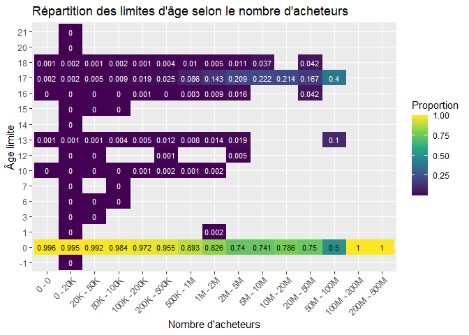

```r
# On copie notre jeu pour ne pas l'altérer
data_age <- jeu_allege

# On trie les jeux dans l'ordre de la limite d'âge la plus basse à la plus haute
data_age$age_cat <- factor(data_age$required_age, levels = sort(unique(data_age$required_age)))

# On calcule la répartition des jeux selon leur âge limite et leur nombre d'acheteurs
repartition_age <- data_age %>%
  count(age_cat, fourchettes_affichage) %>% # On compte le nombre de jeux pour chaque combinaison fourchette d’acheteurs - âge limite
  group_by(fourchettes_affichage) %>% # On regroupe ce décompte par fourchette pour calculer les proportions
  mutate(prop = n / sum(n)) %>% # On ajoute la variable prop, dans laquelle on stocke la proportion de chaque âge limite par fourchette
  ungroup() # On retire la structure groupée

# On crée notre visualisation
ggplot(repartition_age, aes(x = fourchettes_affichage, y = age_cat, fill = prop)) +

  geom_tile() + # On fait une heat map pour montrer la proportion des jeux pour chaque fourchette d'acheteurs et chaque limite d'âge

  geom_text(aes(label = round(prop, 3), color = prop < 0.5), size = 3) + # On ajoute les proportions arrondies à 0,001 sur chaque tile, pour améliorer la lisibilité du graphique

  scale_color_manual(values = c("black", "white"), guide = "none") + # On fait en sorte que les proportions soient lisibles malgré le dégradé de couleurs

  scale_fill_viridis_c() + # On ajoute un système de couleurs adapté aux daltoniens

  labs(
    title = "Répartition des limites d'âge selon le nombre d'acheteurs",
    x = "Nombre d'acheteurs",
    y = "Âge limite",
    fill = "Proportion"
  ) + # On ajoute titre, nom des axes et légende

  theme(axis.text.x = element_text(angle = 45, hjust = 1)) # On incline l'axe des x pour pouvoir lire les fourchettes
```

Sur ce graphique, on peut voir qu’il y a au moins un jeu pour lequel la limite d’âge est égale à -1. Une erreur a pu se glisser lors du nettoyage de notre jeu de données, mais dont la proportion est si faible qu’elle n’empêche pas l’analyse du reste des informations.

Nous constatons avant tout que la grande majorité des jeux n’ont pas de limite d’âge (ligne quasiment entièrement jaune sur l’axe 0).

De plus, il semblerait que plus la fourchette d’acheteurs augmente, plus la proportion de jeux avec une limite d’âge élevée augmente.

Cette constatation va à l’encontre de notre hypothèse, puisque nous pensions qu’un jeu avec une limite d’âge basse serait accessible à un plus grand nombre de joueurs et donc plus acheté. Mais ici, on voit qu’à partir de la fourchette 2-5 millions d’acheteurs, près d’un quart des jeux ont une limite d’âge supérieure ou égale à 17 ans. Cela pourrait s’expliquer par le fait que beaucoup de jeux populaires ont cette limite d’âge, comme *Grand Theft Auto V*, *Call of Duty* ou *Red Dead Redemption 2*.

Enfin, nous pouvons voir que la fourchette 50-100 millions d’acheteurs n’a que 50% de ses jeux qui n’ont pas de limite d’âge, ce qui est normal, puisque, comme nous l’avons vu dans le tableau des 12 jeux les plus vendus, la moitié de ceux composant cette fourchette sont des jeux violents, qui ont donc une limite d’âge élevée : *GTA V*, *HELLDIVERS 2*, *Call of Duty*, *Lost Arc*. Le jeu avec une limite d’âge de 13 ans est *Black Myth: Wukong*. Un des jeux de la fourchette d’acheteurs 50-100 millions d’acheteurs semble d’ailleurs avoir changé de limite d’âge entre le moment où le dataset a été publié et aujourd’hui, puisque *PUBG: Battlefields* est annoncé sans limite d’âge dans notre dataset, mais sur Steam, il est restraint aux plus de 16 ans. Nous détaillerons les genres qu’ils possèdent dans une prochaine visualisation.

## 3ème facteur : les langues supportées

Un facteur qui pourrait également être déterminant pour les ventes d’un jeu est le nombre de langues supportées. Nous allons donc mettre en relation les variables *supported_language* et *estimated_owners* pour répondre à la question :

#### Y a-t-il une corrélation entre les langues supportées par un jeu et ses ventes ?

Il y a beaucoup de langues différentes, donc il est possible que notre visualisation ne soit pas très lisible. Mais étant donné qu’il s’agit d’une analyse exploratoire du jeu de données, il est important de prendre conscience du nombre de langues supportées. Nous voulons voir une répartition, donc un bar chart semble être le plus adapté.

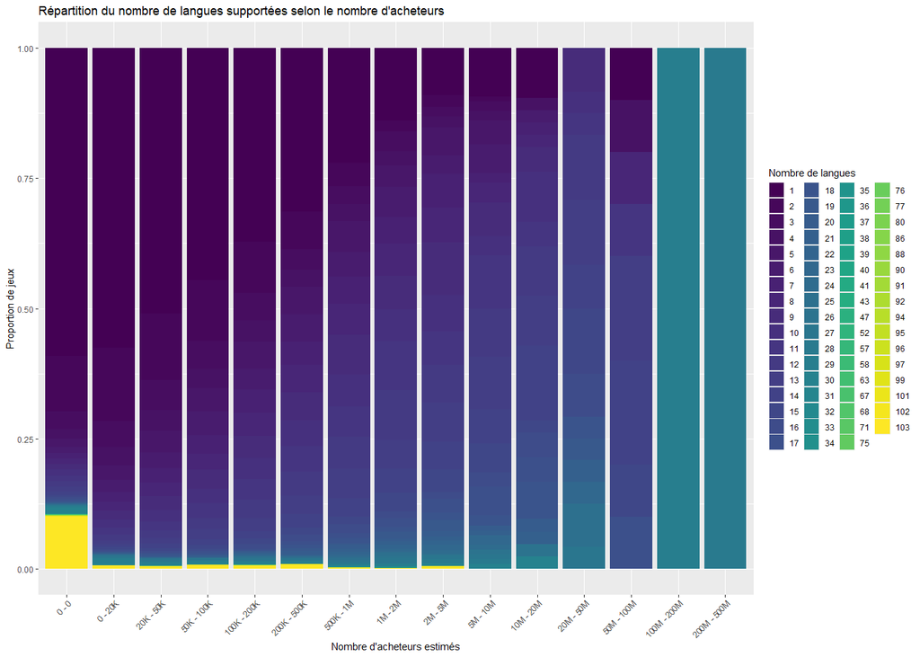

```r
# On copie notre jeu pour ne pas l'altérer
data_langue <- jeu_allege

# On compte le nombre de langues supportées pour chaque jeu
data_langue$nb_langues <- sapply(data_langue$supported_languages, length)

# On calcule la répartition des jeux selon leur nombre de langues supportées et leur nombre d'acheteurs
repartition_langue <- data_langue %>% count(nb_langues, fourchettes_affichage)

# On crée notre visualisation
ggplot(repartition_langue, aes(x = fourchettes_affichage, y = n, fill = factor(nb_langues))) +

  geom_col(position = "fill") + # On rajoute position = fill pour avoir des proportionnalités, et non le nombre précis, pour avoir des barres de même taille et un graphique plus lisible

  scale_fill_viridis_d() + # On ajoute un système de couleurs adapté aux daltoniens

  labs(
    title = "Répartition du nombre de langues supportées selon le nombre d'acheteurs",
    x = "Nombre d'acheteurs estimés",
    y = "Proportion de jeux",
    fill = "Nombre de langues"
  ) + # On ajoute titre, nom des axes et légende

  theme(axis.text.x = element_text(angle = 45, hjust = 1)) # On incline l'axe des x pour pouvoir lire les fourchettes
```

Comme nous nous en doutions, ce graphique est illisible, car il y a trop de nombres possibles de langues supportées. Nous allons donc nous concentrer sur les langues qui figurent parmi les plus parlées au monde : l’anglais, le chinois, l’arabe, le russe, le français, l’espagnol, le portugais, et 2 langues très parlées dans le monde du jeu vidéo : le japonais et le coréen.

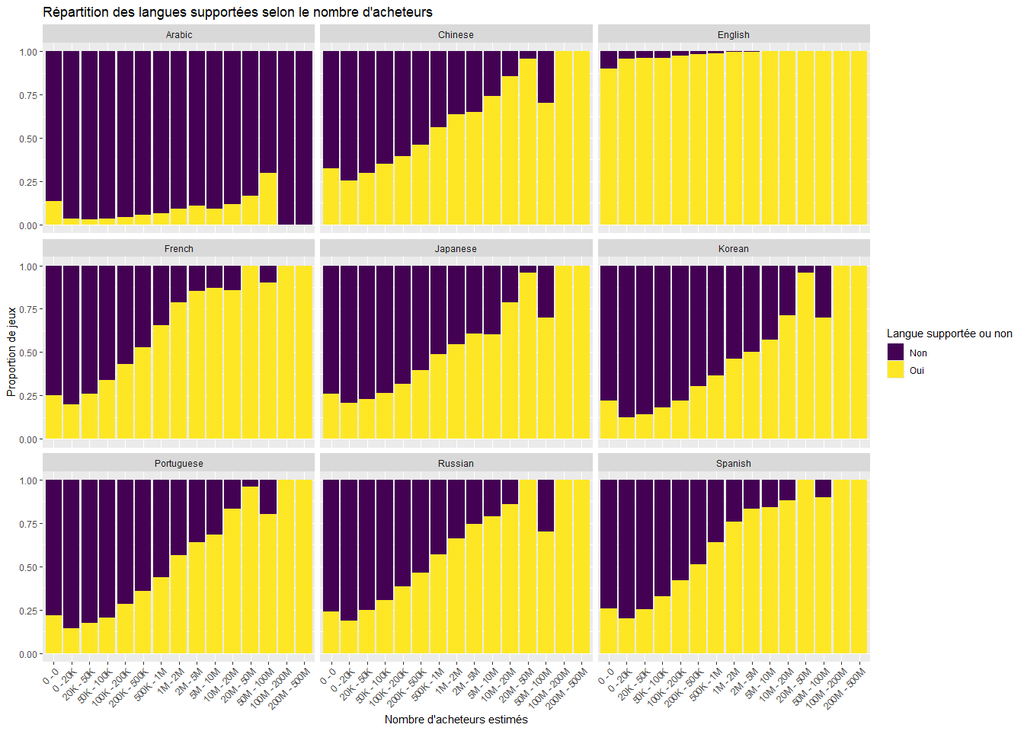

```r
# On fait la liste des langues que l'on veut analyser
langues <- c("English", "French", "Spanish", "Russian", "Chinese", "Arabic", "Portuguese", "Japanese", "Korean")

# On calcule la répartition des jeux selon leur nombre de langues supportées et leur nombre d'acheteurs
repartition <- bind_rows(

   # Pour chaque langue de notre liste...
  lapply(langues, function(langue) {

    # On ajoute une variable pour savoir si elle est supportée ou non
    data_langue %>% mutate(langue = langue, supportee = ifelse(
          str_detect(as.character(supported_languages), paste0("\\b", langue, "\\b")), "Oui", "Non")) %>%
      count(langue, fourchettes_affichage, supportee) # On fait la somme des jeux qui supportent chaque langue pour chaque fourchette d'acheteurs
  })
)

# On crée notre visualisation
ggplot(repartition, aes(x = fourchettes_affichage, y = n, fill = supportee)) +

  geom_col(position = "fill") + # On rajoute position = fill pour avoir des rapports de proportionnalité, et non le nombre précis, pour avoir des barres de même taille et un graphique plus lisible

  scale_fill_viridis_d() + # On ajoute un système de couleurs adapté aux daltoniens

  facet_wrap(~ langue) + # On fait une grille de visualisation montrant les 9 langues étudiées

  labs(
    title = "Répartition des langues supportées selon le nombre d'acheteurs",
    x = "Nombre d'acheteurs estimés",
    y = "Proportion de jeux",
    fill = "Langue supportée ou non"
  ) + # On ajoute titre, nom des axes et légende

  theme(
    axis.text.x = element_text(angle = 45, hjust = 1)) # On incline l'axe des x pour pouvoir lire les fourchettes
```

Grâce à cette visualisation, nous voyons bien que le nombre de langues supportées est corrélé aux nombre de ventes. En effet, quelle que soit la langue, la proportion de jeux la supportant augmente avec le nombre d’acheteurs. Cela semble logique puisque plus un jeu supporte de langues, plus il est accessible à un grand nombre de personnes.

Cependant, il ne sert à rien de supporter toutes les langues du monde, comme nous l’avons vu avec la visualisation précédente, où la grande majorité des jeux avec 103 langues supportées sont invendus.

On peut également voir que la fourchette 50-100 millions d’acheteurs fait exception à la tendance, car ses proportions sont plus faibles pour toutes les langues sauf l’arabe.

Enfin nous pouvons constater que ni *Counter Strike 2* ni *Dota 2* ne supportent la langue arabe, ce qui ne les empêche pas d’avoir les meilleures ventes.

## 4ème facteur : la date de publication

Si nous voulons observer l’impact de différents facteurs sur les ventes d’un jeu, nous pouvons prendre les dates de publication. En effet, il serait intéressant de voir si les nombre de ventes d’un jeu varie selon le mois de publication. Nous allons donc mettre en relation les variables *release_date* et *estimated_owners* pour répondre à la question :

#### Y a-t-il une corrélation entre le mois de publication d’un jeu et ses ventes ?

Le but ici est de voir si, par exemple, plus de monde achète un jeu paru en novembre, juste avant les fêtes, ou en juillet, au début des grandes vacances.

Etant donné qu’on veut voir une évolution au cours du temps, un line chart semble être la visualisation la plus appropriée.

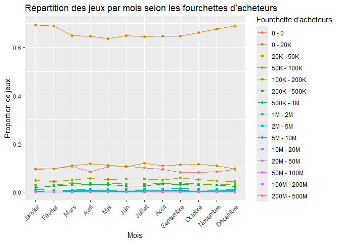

```r
# On copie notre jeu pour ne pas l'altérer
data_date <- jeu_allege

# On ajoute une colonne pour n'avoir que les mois, au format "Janvier", "Février", etc... au lieu de 01, 02, etc...
data_date$mois <- factor(format(data_date$release_date, "%m"), levels = sprintf("%02d", 1:12), labels = c( "Janvier", "Février", "Mars", "Avril", "Mai", "Juin", "Juillet", "Août", "Septembre", "Octobre", "Novembre", "Décembre" ))

# On calcule la répartition des jeux selon leur mois de publication et leur nombre d'acheteurs
repartition_date <- data_date %>%
  count(mois, fourchettes_affichage) %>% # On compte le nombre de jeux pour chaque combinaison fourchette d’acheteurs - mois
  group_by(mois) %>% # On regroupe ce décompte par fourchette pour calculer les proportions
  mutate(prop = n / sum(n)) %>%  # On ajoute la variable prop, dans laquelle on stocke la proportion de chaque mois par fourchette
  ungroup() # On retire la structure groupée

# On crée notre visualisation
ggplot(repartition_date, aes(x = mois, y = prop, color = fourchettes_affichage, group = fourchettes_affichage)) +

  geom_line() + # On fait un line chart pour montrer l'évolution de la proportion
  geom_point() + # On met les points pour mieux voir où s'arrête l'évolution

  labs(
    title = "Répartition des jeux par mois selon les fourchettes d’acheteurs",
    x = "Mois",
    y = "Proportion de jeux",
    color = "Fourchette d’acheteurs"
  ) + # On ajoute titre, nom des axes et légende

  theme(axis.text.x = element_text(angle = 45, hjust = 1)) # On incline l'axe des x pour pouvoir lire les fourchettes
```

Cette visualisation nous permet de voir que la proportion de jeux par fourchette d’acheteurs ne varie pas ou très peu selon le mois de publication. Le mois de publication n’est donc pas un facteur impactant les ventes d’un jeu.

## 5ème facteur : le système d’exploitation

Un autre facteur peut avoir un rôle important lors de l’achat d’un jeu : le système d’exploitaion. En effet, si une personne possède un Mac et un jeu n’est pas supporté par ce système, il y a peu de chances qu’elle l’achète, à moins de faire une machine virtuelle, ce qui est fastidieux. Inversement pour une personne qui a un ordinateur avec le système Winodws et qui souhaite acheter un jeu soutenu exclusivement par Mac.

Cela soulève naturellement la question suivante, à laquelle nous allons répondre avec les varibales *estimated_owners*, *windows*, *linux* et *mac* :

#### Est-ce que le système d’exploitation impacte la vente d’un jeu ?

Puisque nous allons montrer une répartition, nous allons utiliser un bar chart.

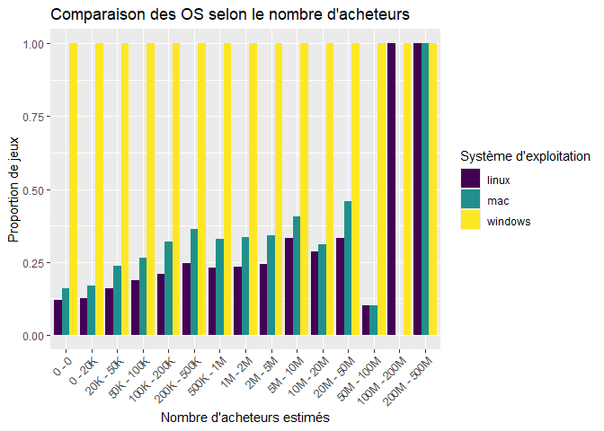

```r
# On copie notre jeu pour ne pas l'altérer
data_sys_expl <- jeu_allege

# On calcule la répartition des jeux selon les systèmes d'exploitation supportés et leur nombre d'acheteurs
repartition_os <- data_sys_expl %>% summarise(
  windows = mean(windows), # proportion de jeux Windows (TRUE = 1, FALSE = 0)
  mac     = mean(mac), # proportion de jeux Mac (TRUE = 1, FALSE = 0)
  linux   = mean(linux), # proportion de jeux Linux (TRUE = 1, FALSE = 0)
  .by = fourchettes_affichage # On regroupe ces proportions par fourchette d'acheteurs
) %>% pivot_longer( # On met chaque OS en colonne, pour avoir une ligne par fourchette
  cols = c(windows, mac, linux),
  names_to = "systeme",
  values_to = "prop"
  )

# On crée notre visualisation
ggplot(repartition_os, aes(x = fourchettes_affichage, y = prop, fill = systeme)) +

  geom_col(position = "dodge") + # On rajoute position = dodge pour avoir les 3 OS côte à côte pour chaque fourchette, avoir un seul graphique au lieu de 3

  scale_fill_viridis_d() + # On ajoute un système de couleurs adapté aux daltoniens

  labs(
    title = "Comparaison des OS selon le nombre d'acheteurs",
    x = "Nombre d'acheteurs estimés",
    y = "Proportion de jeux",
    fill = "Système d'exploitation"
  ) + # On ajoute titre, nom des axes et légende

  theme(axis.text.x = element_text(angle = 45, hjust = 1)) # On incline l'axe des x pour pouvoir lire les fourchettes
```

Cette visualiation nous permet de voir clairement que la proportion de jeux soutenus par les 3 systèmes d’exploitation augmente avec les fourchettes d’acheteurs. On peut donc en déduire que les ventes d’un jeu ont un lien avec le ou les systèmes d’exploitation qui le soutiennent.

On peut également remarquer que Windows soutient tous les jeux de Steam, et que Linux en soutient le moins.

Et enfin, on peut voir que, comme pour les visualisations précédentes (sauf les mois), la fourchette de 50-100 millions d’acheteurs fait exception à la tendance, puisque seulement un de ses jeux est soutenu par Mac et Linux en plus de Windows. Il s’agit de *Unturned*.

## 6ème facteur : le studio de développement

Certains jeux tiennent leur réputation de leur studio de développement, comme les jeux de Riot Games qui ont suivi League of Legends ou ceux étant paru après OverWatch. Le studio de développement peut donc être un facteur d’impact sur les ventes d’un jeu, ce qui révèle la question suivante :

#### Est-ce que le studio de développement impacte la vente d’un jeu ?

Pour répondre à cette question, nous nous servirons des variables *developers* et *estimated_owners*. Etant donné qu’il existe des centaines de studios de développement et par souci de clareté, nous avons décidé de n’analyser que les plus grands studios, c’est-à-dire ceux qui ont développé les jeux les plus vendus. Nous allons donc voir quels studios ont développé les 10 jeux de la fourchette 50-100 millions d’acheteurs, et y ajouter les studios de développement de *Dota 2* et *Counter Strike 2*.

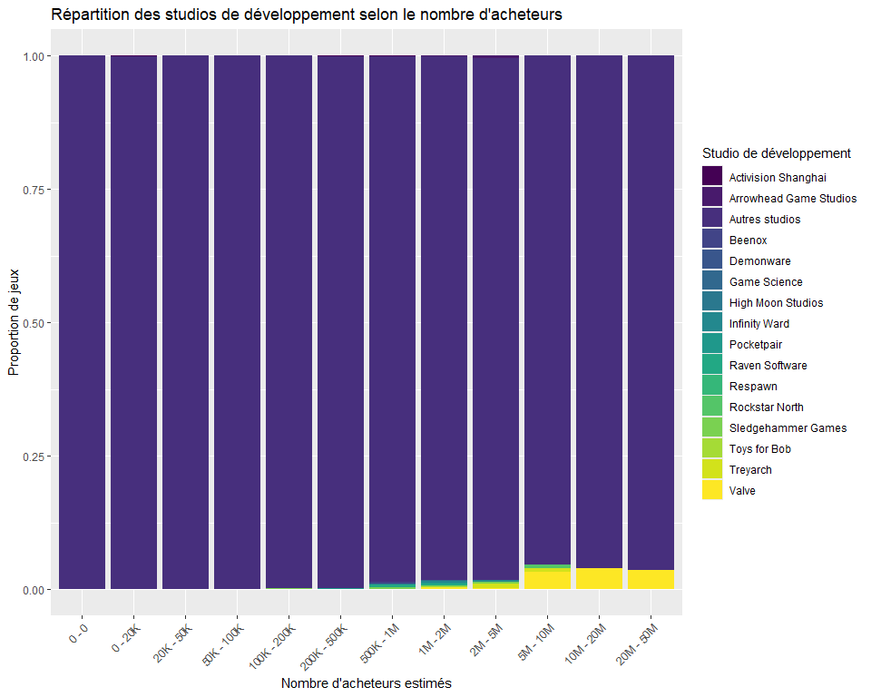

```r
# On copie notre jeu pour ne pas l'altérer et on crée une ligne par studio de développement de chaque jeu, pour compter correctement
data_dev <- jeu_allege %>% unnest(developers)

# On crée notre liste de fourchettes hautes
fourchettes_hautes <- c("50M - 100M", "100M - 200M", "200M - 500M")

# On filtre dans data_dev les studios de developement des 3 fourchettes choisies
studios_geants <- data_dev %>%
  filter(fourchettes_affichage %in% fourchettes_hautes) %>%
  distinct(developers) # On s'assure qu'il n'y a pas de duplicat de studio

# On réunit les autres studios dans la catégorie "Autres studios"
data_dev_full <- data_dev %>%
  mutate(studio = ifelse(developers %in% studios_geants$developers, developers, "Autres studios")) %>%
  filter(!fourchettes_affichage %in% fourchettes_hautes) # On ne garde que les fourchette moyennes et basses, puisqu'on a extirpé les studios des fourchettes hautes

# On calcule la répartition des jeux selon les studios de développement choisis précédemment et leur nombre d'acheteurs
repartition_dev <- data_dev_full %>%
  count(fourchettes_affichage, studio) %>% # On compte le nombre de jeux pour chaque combinaison fourchette d’acheteurs - studio de développement
  group_by(fourchettes_affichage) %>% # On regroupe ce décompte par fourchette pour calculer les proportions
  mutate(prop = n / sum(n)) %>% # On ajoute la variable prop, dans laquelle on stocke la proportion de chaque studio par fourchette
  ungroup() # On retire la structure groupée

# On crée notre visualisation
ggplot(repartition_dev, aes(x = fourchettes_affichage, y = prop, fill = studio)) +

  geom_col() +

  scale_fill_viridis_d() + # On ajoute un système de couleurs adapté aux daltoniens

  labs(
    title = "Répartition des studios de développement selon le nombre d'acheteurs",
    x = "Nombre d'acheteurs estimés",
    y = "Proportion de jeux",
    fill = "Studio de développement"
  ) + # On ajoute titre, nom des axes et légende

  theme(axis.text.x = element_text(angle = 45, hjust = 1)) # On incline l'axe des x pour pouvoir lire les fourchettes
```

Cette visualiation nous permet de voir clairement que parmi les 19 studios de développement qui ont développé les 12 jeux les plus achetés, 1 seul parvient à se démarquer : Valve. En effet, sur les 3 plus grandes fourchettes d’acheteurs, Valve représente environ 5% des jeux achetés, ce qui signifie que 5% des jeux ayant entre 5 et 50 millions d’acheteurs ont été développés par Valve.

Cependant, malgré cette nette démarcation, l’absence d’augmentation réelle et la présence visible d’un seul studio de développement tend à montrer qu’un studio de développement n’impacte pas la vente d’un jeu.

## 7ème facteur : le(s) genre(s)

Il arrive souvent que l’on recherche un jeu par genre : un jeu d’action, d’aventure, de course, de simulation, etc… On pourrait donc supposer que certains genres sont plus populaires que d’autres, et sont donc plus achetés. C’est pour cela que nous allons répondre à la question suivante, grâce aux variables *estimated_owners* et *genres* :

#### Est-ce que le(s) genre(s) impacte la vente d’un jeu ?

Pour vérifier cela, nous allons utiliser une heat map, pour les mêmes raisons que la limite d’âge. En effet, le grand nombre de genres existant rendraient illisible un bar chart ou un line chart.

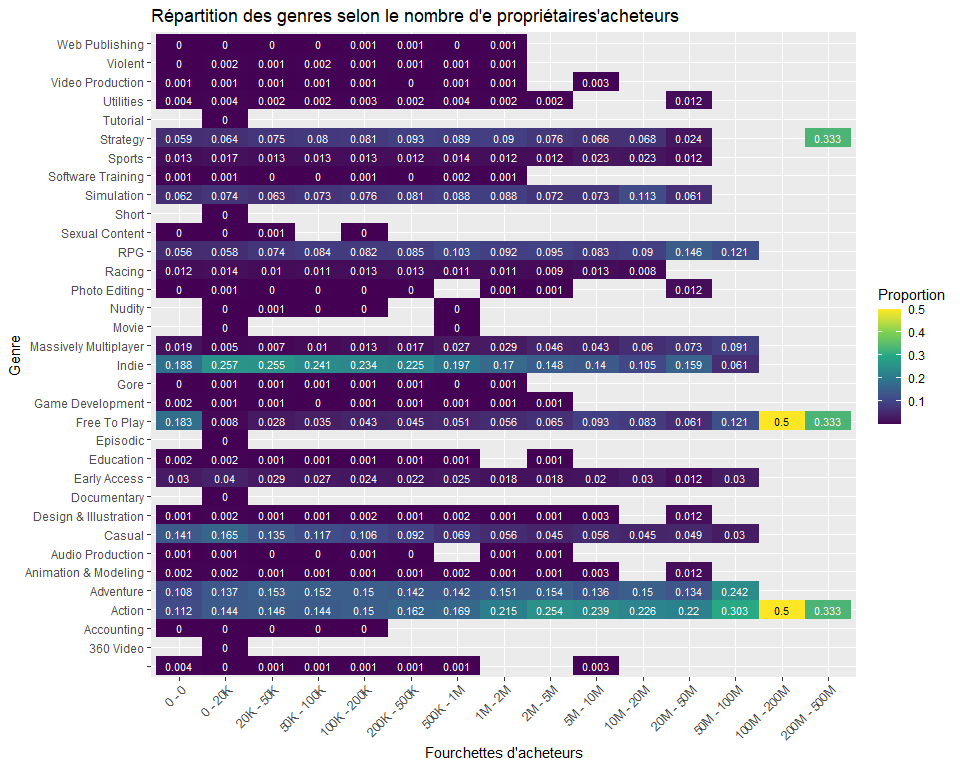

```r
# On copie notre jeu pour ne pas l'altérer et comme pour les studios de développement, on crée une ligne par genre pour chaque jeu
data_genre <- jeu_allege %>% unnest(genres)

# On calcule la répartition des jeux selon leur(s) genre(s) et leur nombre d'acheteurs
repartition_genres <- data_genre %>%
  count(genres, fourchettes_affichage) %>% # On compte le nombre de jeux pour chaque combinaison fourchette d’acheteurs - genre
  group_by(fourchettes_affichage) %>% # On regroupe ce décompte par fourchette pour calculer les proportions
  mutate(prop = n / sum(n)) %>% # On ajoute la variable prop, dans laquelle on stocke la proportion de chaque genre par fourchette
  ungroup() # On retire la structure groupée

# On crée notre visualisation
ggplot(repartition_genres, aes(x = fourchettes_affichage, y = genres, fill = prop)) +

  geom_tile() + # On fait une heat map pour montrer la proportion des jeux pour chaque fourchette d'acheteurs et chaque genre

  geom_text(aes(label = round(prop, 3), color = prop < 0.5), size = 3) + # On ajoute les proportions arrondies à 0,001 sur chaque tile, pour améliorer la lisibilité du graphique

  scale_color_manual(values = c("black", "white"), guide = "none") + # On fait en sorte que les proportions soient lisibles malgré le dégradé de couleurs

  scale_fill_viridis_c() + # On ajoute un système de couleurs adapté aux daltoniens

  labs(
    title = "Répartition des genres selon le nombre d'e propriétaires'acheteurs",
    x = "Fourchettes d'acheteurs",
    y = "Genre",
    fill = "Proportion"
  ) + # On ajoute titre, nom des axes et légende

  theme(axis.text.x = element_text(angle = 45, hjust = 1)) # On incline l'axe des x pour pouvoir lire les fourchettes
```

Avant de commencer à interpréter cette visualisation, il est important de noter qu’un jeu peut avoir plusieurs genres. Donc, lorsque nous dirons “jeu indé” ou “jeu d’aventure”, nous vondrons dire “jeu qui comporte le genre *Inde*” ou “jeu qui comporte le genre *Adventure*”.

Cette visualisation nous permet d’obtenir plusieurs informations.

La première est que les jeux indés représentent près d’un quart des jeux des 5 premières fourchettes, une fois les invendus exclus, ce qui signifie qu’environ 25 % des jeux ayant entre 1 et 500 000 acheteurs sont des jeux indés.

En ce qui concerne l’évolution des proportions au fil des fourchettes, on peut remarquer que la proportion des jeux *Massively Multiplayer* augmente avec le nombre d’acheteurs, tout comme les jeux d’action. Le genre *RPG* augmente aussi, mais plus légèrement. A l’inverse, la proportion de jeux indés et casual baisse avec le nombre de joueurs, tandis que le genre *Adventure* semble stagner.

Toutes ces informations nous font dire que le genre est corrélé au nombre d’acheteurs, et que certains genres populaires poussent les joueurs à acheter les jeux associés. Nous verrons plus tard dans le rapport si cela peut également être lié au nombre d’avis positifs laissés.

Détaillons à présent le paradoxe entre l’âge limite et le genre. Comme nous l’avons vu précédemment, à partir de 2 millions d’acheteurs et jusque 100 millions d’acheteurs, l’âge limite est plus souvent entre 16 et 18 ans que pour les autres fourchettes. Toutefois, lorsque l’on regarde les genres des fourchettes composant cet intervalle, on constate qu’aucun jeu ne comporte *Violent*, *Sexual Content*, *Nudity* ou *Gore*. Pourtant, ce sont ces critères qui sont utilisés pour donner une limite d’âge à un jeu. Après vérification sur la plateforme Steam, nous avons pu constater qu’en effet, ces jeux n’étaient pas catégorisés comme violents ou gores, ce n’était pas une erreur de dataset. On en vient donc à se pose une question : est-ce que les jeux populaires omettent volontairement de s’inscrire dans ces genres pour booster leurs ventes ? Pour éviter de trop inquiéter les joueurs, puisqu’il y a déjà une limite d’âge élevée ? Ou parce qu’on se dit justement que la limite d’âge suffit, et qu’il n’y a pas besoin d’expliciter le genre ?

Cette omission volontaire pourrait expliquer les chiffres des 2 visualisations concernées (âge limite et genre), et tendrait à confirmer que les genres influencent les ventes, certains en bien, *Action*, *Adventure* et *Free To Play*, et d’autres en mal, comme *Violent*, *Nudity* ou *Sexual Content* puisque Steam retire ces genres des jeux les plus achetés.

## Conclusion

Grâce à toutes ces visualisations, nous avons pu constater que plusieurs facteurs peuvent avoir un effet sur les ventes d’un jeu. Les genres semblent avoir le plus d’impact, mais le prix et les langues supportées semblent également jouer un rôle important lors de l’achat d’un jeu.

Pour poursuivre notre analyse du dataset de jeux vidéos, nous adopterons un autre angle afin de répondre à la question suivante :

## Quels facteurs contribuent à l’appréciation d’un jeu ?

Tout d’abord, en parcourant les différentes variables du jeu de données, la mise en relation des colonnes *price* désignant le prix d’un jeu et *pct_pos_total* correspondant à la note attribuée au jeu semblait intéressante. En effet, on s’attendrait que plus on met de l’argent dans un jeu, mieux celui-ci devrait être. Cependant, il est compliqué de réellement de définir ce qu’est la qualité d’un jeu, ainsi nous nous baserons sur l’appréciation qu’ont les joueurs sur un jeu pour définir si le jeu est bien ou non.

D’où la question suivante :

#### Est-ce que les jeux les plus appréciés sont ceux pour lesquels les joueurs paient le plus ?

Tout d’abord, pour répondre à la question, nous avons exploré le jeu de données pour voir s’il était cohérent de représenter dans son entièreté un graphique mettant en relation prix (*price*) et avis positif des jeux (*pct_pos_total*). Nous utiliserons un histogramme pour bien voir la répartition des prix.

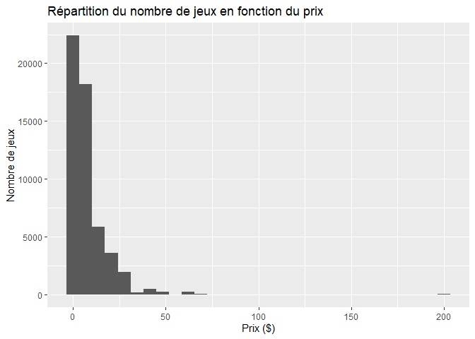

```r
# On ne conserve que les jeux qui ont une note
reviews_prix <- jeu_allege %>% filter(pct_pos_total > 0)

# Histogramme de la répartition du nombre de jeux en fonction du prix
ggplot(reviews_prix, mapping = aes(x = price)) +
  geom_histogram(bins = 30) +
  labs(title = "Répartition du nombre de jeux en fonction du prix", x = "Prix ($)", y = "Nombre de jeux")
```

Après exploration des données, on se rend compte qu’il y a très peu de jeux dont le prix est supérieur à 70 euros, ainsi on décide d’écarter ces jeux pour avoir une meilleure visibilité de la tranche la plus représentée (jeux allant de la gratuité jusqu’à 70 euros). Pour votre curiosité, les quelques jeux se situant aux alentours de 200 euros sont des jeux de puzzle en 3D et sont majoritairement mal notés donc on peut penser qu’ils ne valent pas leur prix.

Regardons maintenant la distribution des notes données aux jeux par tranche de prix (inférieures à 70 euros) :

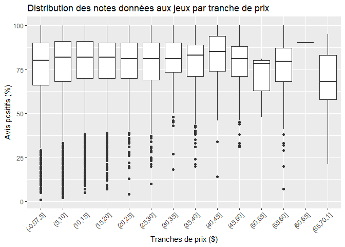

```r
# On ne garde que les jeux possédant une note et dont le prix est inférieur à 70 euros.
reviews_prix <- jeu_allege %>% filter(pct_pos_total > 0, price < 70)

# Graphique présentant la distribution des notes données aux jeux par tranche de prix. (Mettre en relation avec un nuage de points les avis positifs avec les prix rendait le tout illisible.)

ggplot(reviews_prix, mapping = aes(x = cut(price, breaks = 14), y = pct_pos_total)) + # On sépare de manière à avoir des tranches de prix allant de 5 par 5
  geom_boxplot() +
  labs(title = "Distribution des notes données aux jeux par tranche de prix", x = "Tranches de prix ($)", y = "Avis positifs (%)") +
  theme(axis.text.x = element_text(angle = 45, hjust = 1)) # Les intervalles sont illisibles sinon
```

On voit d’après le graphique que pour chaque tranche de prix, le pourcentage d’avis positif reste à priori le même. Ainsi, on ne peut pas vraiment dire qu’il y a de lien entre l’appréciation d’un jeu et son prix. Cependant, ce graphique ne nous indique pas à quel point la note d’un jeu sera fiable ou non car on ne connait pas la distribution du nombre de reviews pour chaque tranche de prix. En effet, une évaluation positive a peu d’intérêt si peu d’utilisateurs ont participé à celle-ci. D’où la question suivante :

#### Quel est le nombre de reviews moyen qui ont été attribuées pour chaque tranche de prix ?

Pour répondre à cette question, on souhaite mettre en relation le nombre de reviews de jeux (**num_reviews_total**) avec des tranches de prix allant de 5 à 5 (**price**). On peut s’attendre à ce que le nombre de reviews moyen soit le même pour chaque tranche, nous ne voyons pas particulièrement de raison qui ferait qu’une tranche aurait plus de reviews qu’une autre.

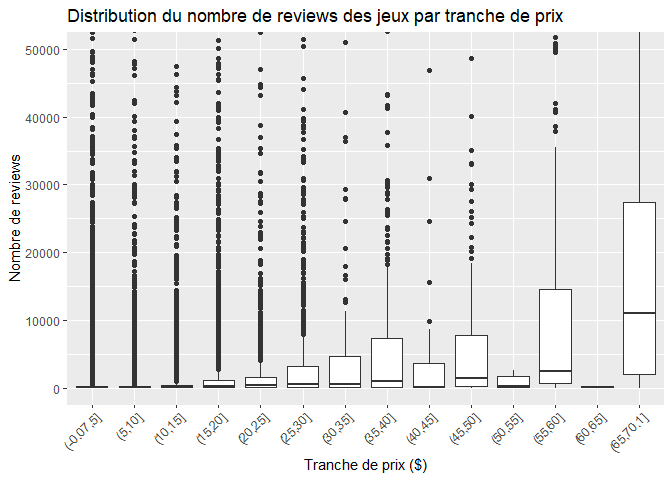

```r
# Mêmes données que précédemment
reviews_prix <- jeu_allege %>% filter(pct_pos_total > 0, price < 70)

# Graphique présentant la distribution du nombre de reviews des jeux par tranche de prix.

ggplot(reviews_prix, mapping = aes(x = cut(price, breaks = 14), y = num_reviews_total)) +
  geom_boxplot() +
  coord_cartesian(ylim = c(0, 50000)) +
  labs(title = "Distribution du nombre de reviews des jeux par tranche de prix", y = "Nombre de reviews", x = "Tranche de prix ($)") +
  theme(axis.text.x = element_text(angle = 45, hjust = 1)) # Les intervalles sont illisibles sinon
```

On constate que plus le jeu est cher, plus on a d’avis et donc de notes à propos de celui-ci. Ainsi on peut imaginer que les notes qui sont attribuées à un jeu à prix élevé sont plus fiables (car plus nombreuses) que pour un jeu peu coûteux voire gratuit.

En plus de regarder les prix, il est intéressant de surveiller l’évolution de l’appréciation des utilisateurs au fil du temps, ainsi nous allons utiliser les variables *pct_pos_total* et *release_date* afin de réponse à la question suivante :

### L’appréciation des jeux évolue t-elle au fil du temps ?

Dans un premier temps, pour répondre à la question, il est important de connaître la répartition du nombre de jeux par année. On s’attend à ce que plus on avance dans le temps, plus il y a de jeux car, avec le temps, il est de plus en plus simple de concevoir son jeu.

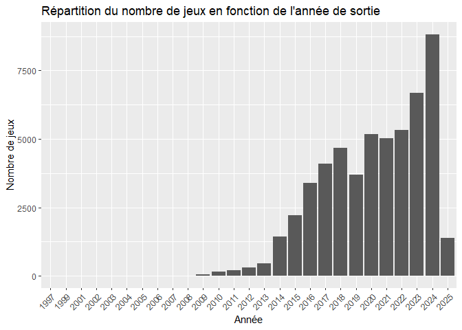

```r
# On ne garde que les années aux dates
reviews_prix$release_year <- substr(reviews_prix$release_date, 1, 4)

# Histogramme de la répartition du nombre de jeux en fonction de l'année de sortie
ggplot(reviews_prix, mapping = aes(x = release_year)) +
  geom_bar() +
  labs(title = "Répartition du nombre de jeux en fonction de l'année de sortie", x = "Année", y = "Nombre de jeux") +
  theme(axis.text.x = element_text(angle = 45, hjust = 1)) # Les intervalles sont illisibles sinon
```

```r
# On souhaite connaître le nombre de jeux avec des reviews avant 2008 (non visible sur le graphique)
reviews_prix %>% filter(release_year < 2008) %>% count()
```

```
##    n
## 1 30
```

On remarque qu’il n’y a que 30 jeux avec des reviews avant 2008, ainsi on s’intéressera aux jeux après cette année pour mieux analyser l’évolution des reviews positives de jeux. Pour ce qui est de l’évolution des reviews positives de jeux, on s’attend que plus on avance dans le temps, mieux les jeux seront notés car avec le temps, de nouvelles technologies apparaissent pour améliorer la qualité des jeux (meilleurs graphismes, meilleures IA).

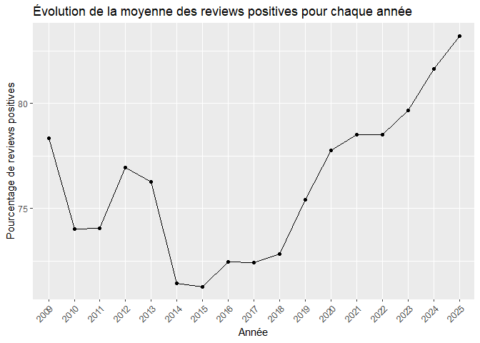

```r
# On retire les jeux n'ayant pas du tout de reviews.
jeux_to_evaluate <- reviews_prix %>% filter(pct_pos_total > 0, release_year > 2008)
jeux_to_evaluate$release_year <- substr(jeux_to_evaluate$release_date, 1, 4)
mean_by_year <- aggregate(pct_pos_total ~ release_year, data=jeux_to_evaluate, mean)

# Graphique présentant la distribution du nombre de reviews des jeux par tranche de prix.

ggplot(mean_by_year, mapping = aes(x = release_year, y = pct_pos_total, group=1)) +
  geom_point() +
  geom_line() +
  labs(title = "Évolution de la moyenne des reviews positives pour chaque année", y = "Pourcentage de reviews positives", x = "Année") +
  theme(axis.text.x = element_text(angle = 45, hjust = 1)) # Les intervalles sont illisibles sinon
```

Conformément à notre hypothèse, les jeux sont de mieux en mieux notés au fil des années. Cependant, on remarque qu’en 2014 et 2015, beaucoup de jeux ont été mal notés. Après quelques recherches il semblerait que ces années correspondent à la sortie de la feature laissant la possibilité aux jeux d’être sortis en version beta-test. Ainsi, les jeux de cette année ne seraient pas forcément finis au moment de leur sortie et pouvaient comporter des bugs pouvant nuire à l’expérience utilisateur du joueur. Dans ce cas, les joueurs frustrés de ces jeux auraient pu mettre des moins bonnes reviews à ce moment là.

En outre, une autre manière de comprendre quel type de jeu sont les plus appréciés est de regarder les genres qui sont préférés par les joueurs d’où la question suivante :

### Quels genres sont les plus appréciés ?

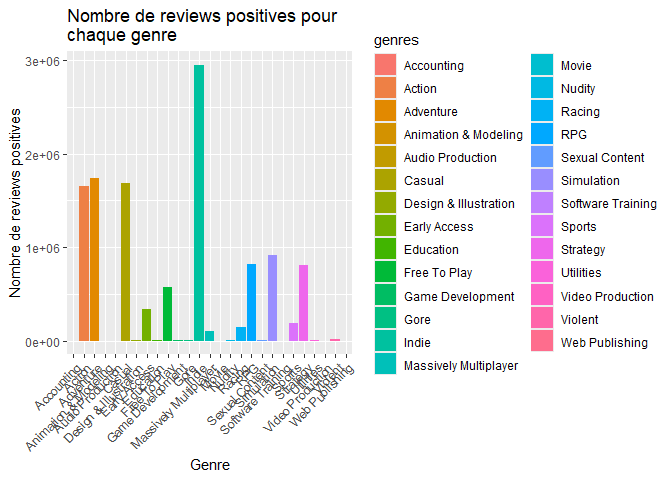

```r
# Pour mieux compter les genres
jeux_genres_separes <- jeu_allege %>% unnest(genres)

# On retire les jeux qui n'ont pas de reviews
jeux_genres_separes <- jeux_genres_separes %>% filter(pct_pos_total > 0, genres != "")

# Graphique présentant la distribution du nombre de reviews des jeux par genre.
ggplot(jeux_genres_separes, mapping = aes(x = genres, y = pct_pos_total, group = 1, fill = genres)) +
  geom_bar(stat = "identity") +
  labs(title = "Nombre de reviews positives pour \nchaque genre", y = "Nombre de reviews positives", x = "Genre") +
  theme(axis.text.x = element_text(angle = 45, hjust = 1)) # Les intervalles sont illisibles sinon
```

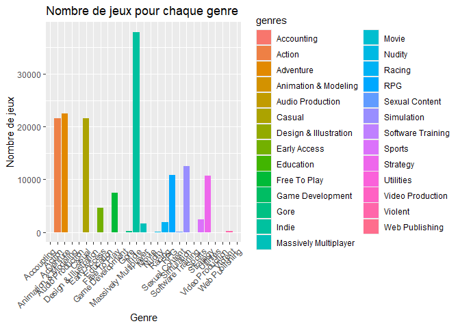

```r
# Graphique présentant la distribution du nombre de jeux par genre.
ggplot(jeux_genres_separes, mapping = aes(x = genres, fill = genres)) +
  geom_bar() +
  labs(title = "Nombre de jeux pour chaque genre", y = "Nombre de jeux", x = "Genre") +
  theme(axis.text.x = element_text(angle = 45, hjust = 1)) # Les intervalles sont illisibles sinon
```

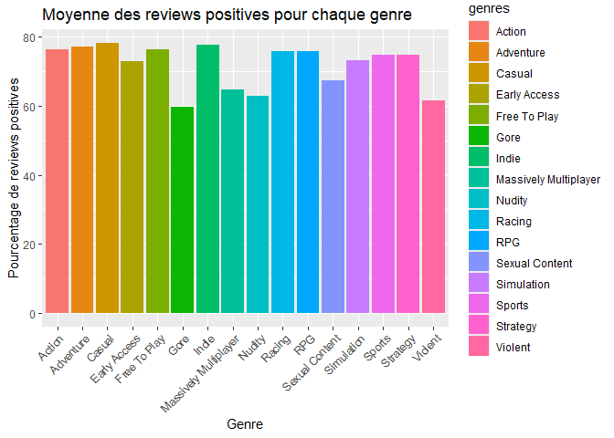

```r
# On garde uniquement les genres qui concernent + de 50 jeux (n'a pas de sens d'évaluer la moyenne sur un petit échantillon)
genres_valides <- jeux_genres_separes %>% count(genres) %>% filter(n >= 50) %>% pull(genres)

# On calcule la moyenne pour chaque genre
mean_by_genre <- aggregate(pct_pos_total ~ genres, data=filter(jeux_genres_separes, genres %in% genres_valides), mean)

# Graphique présentant la moyenne des reviews positives pour chaque genre
ggplot(mean_by_genre, mapping = aes(x = genres, y = pct_pos_total, group = 1, fill = genres)) +
  geom_bar(stat = "identity") +
  labs(title = "Moyenne des reviews positives pour chaque genre", y = "Pourcentage de reviews positives", x = "Genre") +
  theme(axis.text.x = element_text(angle = 45, hjust = 1)) # Les intervalles sont illisibles sinon
```

On constate que les genres les moins appréciés sont “Gore” et “Violent”. On peut faire l’hypothèse que c’est parce que tout le monde n’est pas à l’aise avec de tels concepts. Les genres les plus appréciés sont “Adventure”, “Casual” et “Indie”. Il s’agit potentiellement de genres n’apportant pas de frustration aux joueurs ce qui peut expliquer le fait qu’ils soient aussi bien notés.

Il serait aussi intéressant de voir quels sont les genres où les joueurs passent le plus de temps.

### Quels sont les genres où les joueurs ont passé le plus de temps en moyenne ?

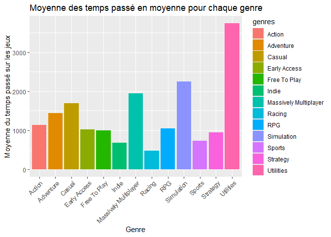

```r
jeux_genres_separes <- jeu_allege %>% unnest(genres)
jeux_genres_separes <- jeux_genres_separes %>% filter(average_playtime_forever > 0)
# On garde uniquement les genres qui concernent + de 50 jeux (n'a pas de sens d'évaluer la moyenne sur un petit échantillon)
genres_valides <- jeux_genres_separes %>% count(genres) %>% filter(n >= 50) %>% pull(genres)

# On calcule la moyenne pour chaque genre
mean_by_genre <- aggregate(average_playtime_forever ~ genres, data=filter(jeux_genres_separes, genres %in% genres_valides), mean)

# Graphique présentant la moyenne des temps moyens passés pour chaque genre
ggplot(mean_by_genre, mapping = aes(x = genres, y = average_playtime_forever, group = 1, fill = genres)) +
  geom_bar(stat = "identity") +
  labs(title = "Moyenne des temps passé en moyenne pour chaque genre", y = "Moyenne du temps passé sur les jeux", x = "Genre") +
  theme(axis.text.x = element_text(angle = 45, hjust = 1)) # Les intervalles sont illisibles sinon
```

Contrairement à nos attentes, le genre pour lequel les joueurs passent le plus de temps est “Utilities”. Ce genre n’indique pas vraiment des jeux car après vérification, le type d’application présent dans ce genre sont majoritairement des applications aidant à créer des jeux. Cela montre que les utilisateurs de steam ne sont pas seulement des joueurs mais qu’il y a aussi des développeurs qui passent beaucoup de temps sur les applications les aidant à créer leur jeu. Cela montre aussi que cela prend beaucoup plus de temps de créer un jeu que de jouer à celui-ci. En outre, les genres plus liés aux joueurs de jeux vidéos, où les personnes passent le plus leur temps sont les jeux de simulation, les jeux multijoueurs et les jeux casuals. Ce résultat ne nous paraît pas si surprenant, la plupart des influenceurs gaming jouent à ce type de jeu et on peut imaginer que c’est leur influence qui fait que beaucoup de joueurs se retrouvent à jouer également. De plus, on remarque que les jeux les moins joués justement sont les jeux indés et les jeux de course. On peut imaginer que pour ce qui concerne les jeux indés, ils sont majoritairement plus courts à finir que les autres jeux en raison de leurs coûts de production moins élevés que ce qu’aurait une grande entreprise. Pour ce qui concerne les jeux de course, on peut imaginer que c’est parce qu’on jouera majoritairement à ce type de jeux avec des amis que tout seul.